# Advertisment IP

### checking correlation

```r
#correlation for numerical colunms
#
cor(Numeric)
```

```
##                          Daily.Time.Spent.on.Site         Age  Area.Income
## Daily.Time.Spent.on.Site               1.00000000 -0.33151334  0.310954413
## Age                                   -0.33151334  1.00000000 -0.182604955
## Area.Income                            0.31095441 -0.18260496  1.000000000
## Daily.Internet.Usage                   0.51865848 -0.36720856  0.337495533
## Male                                  -0.01895085 -0.02104406  0.001322359
## Clicked.on.Ad                         -0.74811656  0.49253127 -0.476254628
##                          Daily.Internet.Usage         Male Clicked.on.Ad
## Daily.Time.Spent.on.Site           0.51865848 -0.018950855   -0.74811656
## Age                               -0.36720856 -0.021044064    0.49253127
## Area.Income                        0.33749553  0.001322359   -0.47625463
## Daily.Internet.Usage               1.00000000  0.028012326   -0.78653918
## Male                               0.02801233  1.000000000   -0.03802747
## Clicked.on.Ad                     -0.78653918 -0.038027466    1.00000000
```

## #plotting correlation of the numerical variables

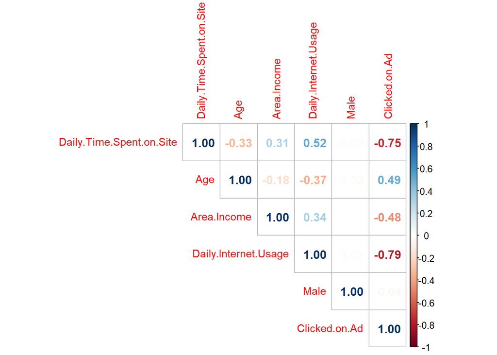

```r
# install.packages("corrplot")
library(corrplot)
#
## Let’s build a correlation matrix to understand the relation between each attributes
corrplot(cor(Numeric), type = 'upper', method = 'number', tl.cex = 0.9)# using a heat map to visualize variable correlations
```

## We can model the relationship between these variables by fitting a linear equation

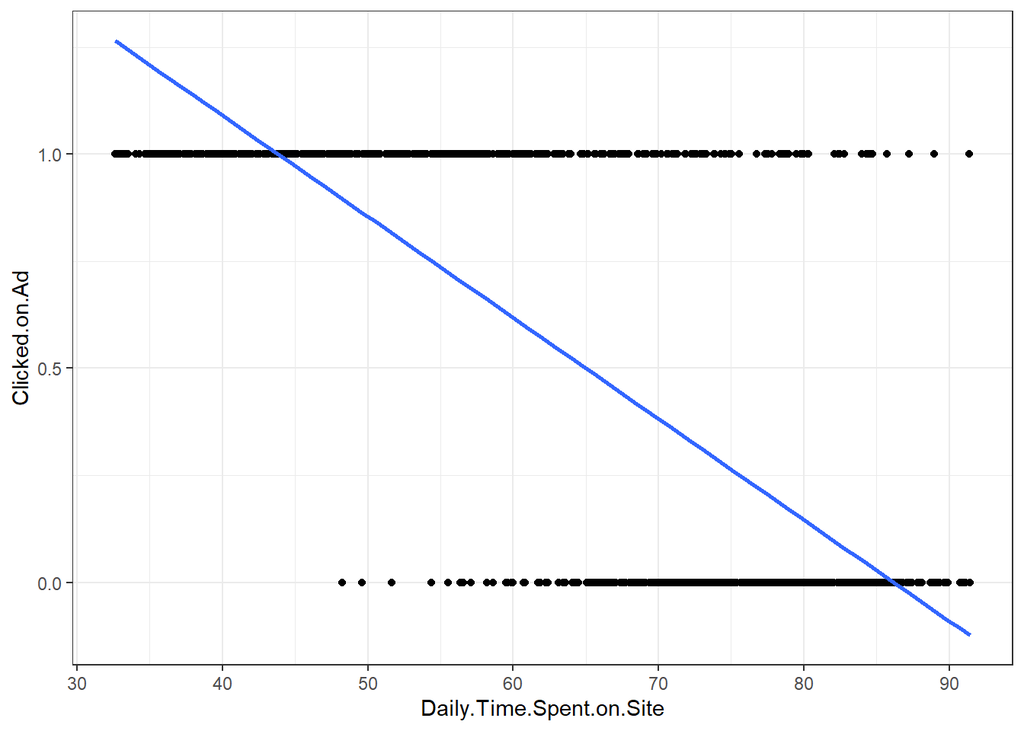

```r
# Relationship between "Daily.Time.Spent.on.Site" and "Clicked.on.Ad"
#
ggplot(Numeric, aes(x = Daily.Time.Spent.on.Site, y =Clicked.on.Ad)) +
  geom_point() +
  geom_smooth(method = 'lm', se = FALSE) +
  theme_bw()
```

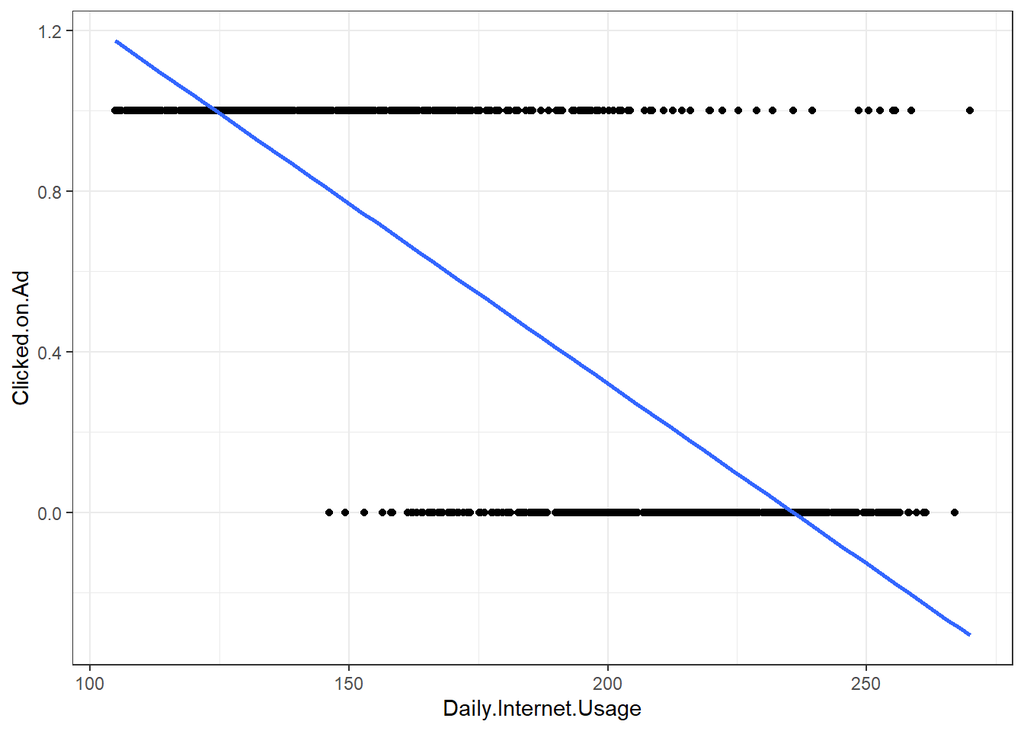

```r
# Relationship between "Daily.Internet.Usage" and "Clicked.on.Ad"
#
ggplot(Numeric, aes(x = Daily.Internet.Usage, y =Clicked.on.Ad)) +
  geom_point() +
  geom_smooth(method = 'lm', se = FALSE) +
  theme_bw()
```

observation: from the 2 scatter plots above, there is a high negative correlation between the pairs, Therefore, we will have to drop one variable to reduce dimensionality and redundancy.

## Dropping the highly correlated columns

```r
# selecting highly correlated column to be dropped
to_drop <- c("Daily.Internet.Usage")
#
#dropping the highly correlated colunms
#
my_dataset <- my_dataset[, !names(my_dataset) %in% to_drop]
head(my_dataset)
```

| Daily.Time.Spent.on.Site | Age | Area.Income | Ad.Topic.Line | City | Male | Country | Timestamp | Clicked.on.Ad |
| --- | --- | --- | --- | --- | --- | --- | --- | --- |
| 68.95 | 35 | 61833.90 | Cloned 5thgeneration orchestration | Wrightburgh | 0 | Tunisia | 2016-03-27 00:53:11 | 0 |
| 80.23 | 31 | 68441.85 | Monitored national standardization | West Jodi | 1 | Nauru | 2016-04-04 01:39:02 | 0 |
| 69.47 | 26 | 59785.94 | Organic bottom-line service-desk | Davidton | 0 | San Marino | 2016-03-13 20:35:42 | 0 |
| 74.15 | 29 | 54806.18 | Triple-buffered reciprocal time-frame | West Terrifurt | 1 | Italy | 2016-01-10 02:31:19 | 0 |
| 68.37 | 35 | 73889.99 | Robust logistical utilization | South Manuel | 0 | Iceland | 2016-06-03 03:36:18 | 0 |
| 59.99 | 23 | 59761.56 | Sharable client-driven software | Jamieberg | 1 | Norway | 2016-05-19 14:30:17 | 0 |

### Numerical colunms after dropping highly correlated colunms

```r
# getting the numerical columns from the new and revised dataframe
#Checking the data types of the columns
#
New_numeric<- my_dataset %>% select_if(is.numeric)
New_numeric
```

| Daily.Time.Spent.on.Site | Age | Area.Income | Male | Clicked.on.Ad |
| --- | --- | --- | --- | --- |
| 68.95 | 35 | 61833.90 | 0 | 0 |
| 80.23 | 31 | 68441.85 | 1 | 0 |
| 69.47 | 26 | 59785.94 | 0 | 0 |
| 74.15 | 29 | 54806.18 | 1 | 0 |
| 68.37 | 35 | 73889.99 | 0 | 0 |
| 59.99 | 23 | 59761.56 | 1 | 0 |
| 88.91 | 33 | 53852.85 | 0 | 0 |
| 66.00 | 48 | 24593.33 | 1 | 1 |
| 74.53 | 30 | 68862.00 | 1 | 0 |
| 69.88 | 20 | 55642.32 | 1 | 0 |

[output cut: 990 more lines]

# Ploting correlation of the after dropping one colunm

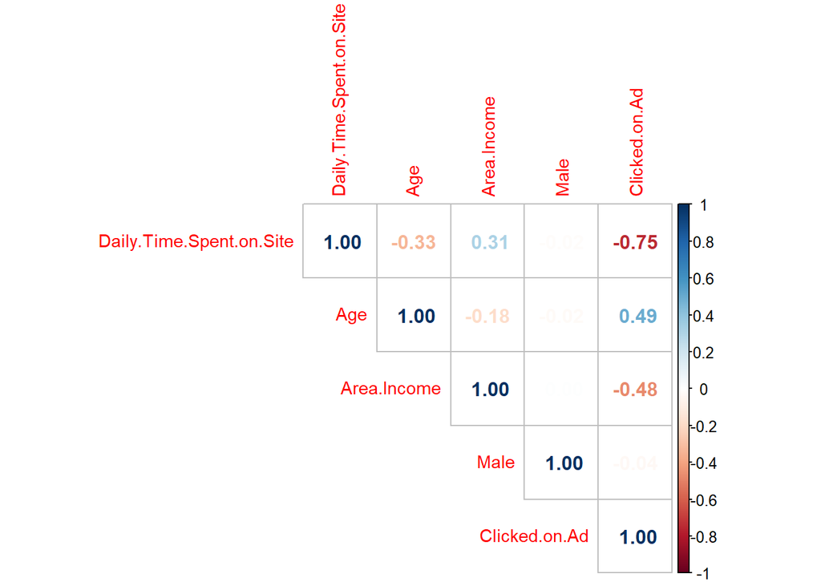

```r
## Let’s build a correlation matrix to understand the relation between each attributes
corrplot(cor(New_numeric), type = 'upper', method = 'number', tl.cex = 0.9)
```

Removing the highly correlated variables has reduced multicollinearity in our dataset. It also made it easier to proceed with the modeling.

### Dropping other irrelevant colunms

```r
# dropping the irrelevant columns
to_drop <- c("Timestamp","City")
my_dataset <- my_dataset[, !names(my_dataset) %in% to_drop]
head(my_dataset)
```

| Daily.Time.Spent.on.Site | Age | Area.Income | Ad.Topic.Line | Male | Country | Clicked.on.Ad |
| --- | --- | --- | --- | --- | --- | --- |
| 68.95 | 35 | 61833.90 | Cloned 5thgeneration orchestration | 0 | Tunisia | 0 |
| 80.23 | 31 | 68441.85 | Monitored national standardization | 1 | Nauru | 0 |
| 69.47 | 26 | 59785.94 | Organic bottom-line service-desk | 0 | San Marino | 0 |
| 74.15 | 29 | 54806.18 | Triple-buffered reciprocal time-frame | 1 | Italy | 0 |
| 68.37 | 35 | 73889.99 | Robust logistical utilization | 0 | Iceland | 0 |
| 59.99 | 23 | 59761.56 | Sharable client-driven software | 1 | Norway | 0 |

## Modeling

### Supervised Learning

This is the modeling where there is features/independent and target/label/dependent variables.

## Feature Engineering

```r
#installing libraries to help in computation
# install.packages("caret")
library(lattice)
library(caret, warn.conflicts = FALSE)
#previewing the dataset
#
head(my_dataset)
```

| Daily.Time.Spent.on.Site | Age | Area.Income | Ad.Topic.Line | Male | Country | Clicked.on.Ad |
| --- | --- | --- | --- | --- | --- | --- |
| 68.95 | 35 | 61833.90 | Cloned 5thgeneration orchestration | 0 | Tunisia | 0 |
| 80.23 | 31 | 68441.85 | Monitored national standardization | 1 | Nauru | 0 |
| 69.47 | 26 | 59785.94 | Organic bottom-line service-desk | 0 | San Marino | 0 |
| 74.15 | 29 | 54806.18 | Triple-buffered reciprocal time-frame | 1 | Italy | 0 |
| 68.37 | 35 | 73889.99 | Robust logistical utilization | 0 | Iceland | 0 |
| 59.99 | 23 | 59761.56 | Sharable client-driven software | 1 | Norway | 0 |

##checking dataset datatype

```r
str(my_dataset)
```

```
## tibble [1,000 x 7] (S3: tbl_df/tbl/data.frame)
##  $ Daily.Time.Spent.on.Site: num [1:1000] 69 80.2 69.5 74.2 68.4 ...
##  $ Age                     : int [1:1000] 35 31 26 29 35 23 33 48 30 20 ...
##  $ Area.Income             : num [1:1000] 61834 68442 59786 54806 73890 ...
##  $ Ad.Topic.Line           : chr [1:1000] "Cloned 5thgeneration orchestration" "Monitored national standardization" "Organic bottom-line service-desk" "Triple-buffered reciprocal time-frame" ...
##  $ Male                    : int [1:1000] 0 1 0 1 0 1 0 1 1 1 ...
##  $ Country                 : chr [1:1000] "Tunisia" "Nauru" "San Marino" "Italy" ...
##  $ Clicked.on.Ad           : int [1:1000] 0 0 0 0 0 0 0 1 0 0 ...
```

##converting charatcter varaible to factors

```r
#loading libraries
library(caret)
library(lattice)
library(ggplot2)
#
# converting to factor
my_dataset$Ad.Topic.Line <- as.factor(my_dataset$Ad.Topic.Line)
my_dataset$Country <- as.factor(my_dataset$Country)
```

```r
#confirming new datatype.
#
str(my_dataset)
```

```
## tibble [1,000 x 7] (S3: tbl_df/tbl/data.frame)
##  $ Daily.Time.Spent.on.Site: num [1:1000] 69 80.2 69.5 74.2 68.4 ...
##  $ Age                     : int [1:1000] 35 31 26 29 35 23 33 48 30 20 ...
##  $ Area.Income             : num [1:1000] 61834 68442 59786 54806 73890 ...
##  $ Ad.Topic.Line           : Factor w/ 1000 levels "Adaptive 24hour Graphic Interface",..: 92 465 567 904 767 806 223 724 108 455 ...
##  $ Male                    : int [1:1000] 0 1 0 1 0 1 0 1 1 1 ...
##  $ Country                 : Factor w/ 237 levels "Afghanistan",..: 216 148 185 104 97 159 146 13 83 79 ...
##  $ Clicked.on.Ad           : int [1:1000] 0 0 0 0 0 0 0 1 0 0 ...
```

Now our data has numerical, integer and factor data types.

### converting factors to numeric

```r
#converting to numerical
#
new_dataset<- my_dataset
new_dataset$Ad.Topic.Line <- as.numeric(new_dataset$Ad.Topic.Line)
new_dataset$Country <- as.numeric(new_dataset$Country)
new_dataset
```

| Daily.Time.Spent.on.Site | Age | Area.Income | Ad.Topic.Line | Male | Country | Clicked.on.Ad |
| --- | --- | --- | --- | --- | --- | --- |
| 68.95 | 35 | 61833.90 | 92 | 0 | 216 | 0 |
| 80.23 | 31 | 68441.85 | 465 | 1 | 148 | 0 |
| 69.47 | 26 | 59785.94 | 567 | 0 | 185 | 0 |
| 74.15 | 29 | 54806.18 | 904 | 1 | 104 | 0 |
| 68.37 | 35 | 73889.99 | 767 | 0 | 97 | 0 |
| 59.99 | 23 | 59761.56 | 806 | 1 | 159 | 0 |
| 88.91 | 33 | 53852.85 | 223 | 0 | 146 | 0 |
| 66.00 | 48 | 24593.33 | 724 | 1 | 13 | 1 |
| 74.53 | 30 | 68862.00 | 108 | 1 | 83 | 0 |
| 69.88 | 20 | 55642.32 | 455 | 1 | 79 | 0 |

[output cut: 990 more lines]

```r
str(new_dataset)
```

```
## tibble [1,000 x 7] (S3: tbl_df/tbl/data.frame)
##  $ Daily.Time.Spent.on.Site: num [1:1000] 69 80.2 69.5 74.2 68.4 ...
##  $ Age                     : int [1:1000] 35 31 26 29 35 23 33 48 30 20 ...
##  $ Area.Income             : num [1:1000] 61834 68442 59786 54806 73890 ...
##  $ Ad.Topic.Line           : num [1:1000] 92 465 567 904 767 806 223 724 108 455 ...
##  $ Male                    : int [1:1000] 0 1 0 1 0 1 0 1 1 1 ...
##  $ Country                 : num [1:1000] 216 148 185 104 97 159 146 13 83 79 ...
##  $ Clicked.on.Ad           : int [1:1000] 0 0 0 0 0 0 0 1 0 0 ...
```

```r
# ensure the results are repeatable
set.seed(7)
# load the library
library(caret)
# calculate correlation matrix
correlationMatrix <- cor(new_dataset[,1:6])
# summarize the correlation matrix
print(correlationMatrix)
```

```
##                          Daily.Time.Spent.on.Site          Age  Area.Income
## Daily.Time.Spent.on.Site               1.00000000 -0.331513343  0.310954413
## Age                                   -0.33151334  1.000000000 -0.182604955
## Area.Income                            0.31095441 -0.182604955  1.000000000
## Ad.Topic.Line                         -0.01835594 -0.018530290 -0.032300256
## Male                                  -0.01895085 -0.021044064  0.001322359
## Country                               -0.01185169  0.002460338  0.046440538
##                          Ad.Topic.Line         Male      Country
## Daily.Time.Spent.on.Site   -0.01835594 -0.018950855 -0.011851695
## Age                        -0.01853029 -0.021044064  0.002460338
## Area.Income                -0.03230026  0.001322359  0.046440538
## Ad.Topic.Line               1.00000000 -0.025281966  0.044460331
## Male                       -0.02528197  1.000000000 -0.015595618
## Country                     0.04446033 -0.015595618  1.000000000
```

```r
# find attributes that are highly corrected (ideally >0.75)
highlyCorrelated <- findCorrelation(correlationMatrix, cutoff=0.5)
# print indexes of highly correlated attributes
print(highlyCorrelated)
```

```
## integer(0)
```

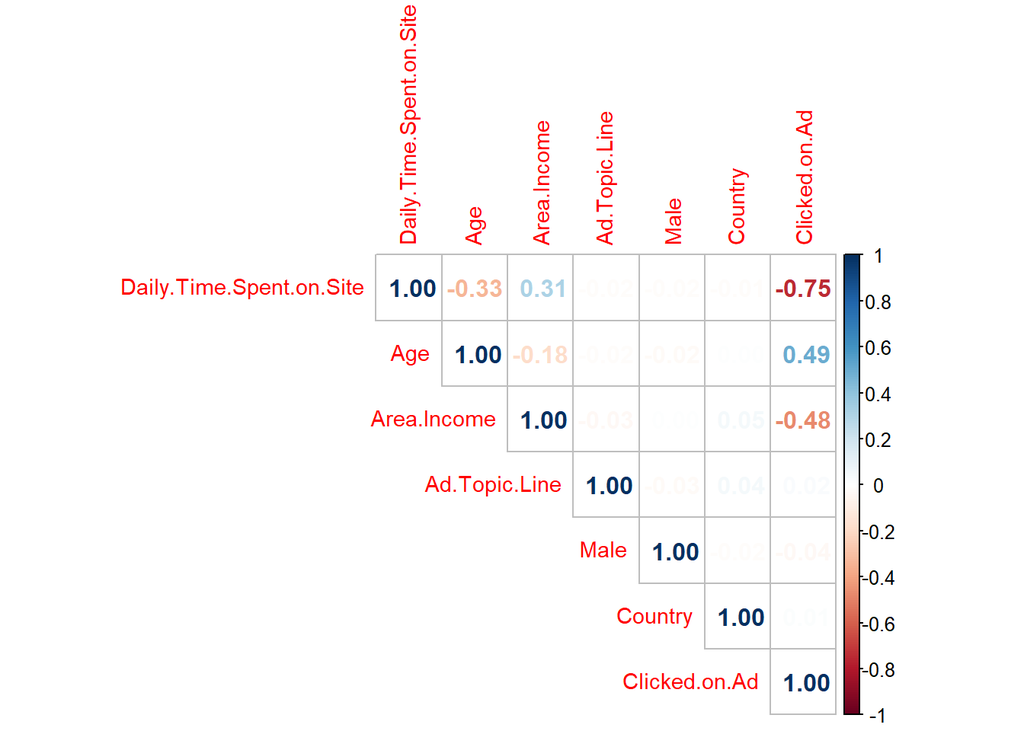

```r
## Let’s build a correlation matrix to understand the relation between each attributes
corrplot(cor(new_dataset), type = 'upper', method = 'number', tl.cex = 0.9)
```

There is no variable above correlation of 0.75. thus we can continue with the modeling.

## Decision Trees

```r
# shuffling our data set to randomize the records
shuffle_index <- sample(1:nrow(new_dataset))
new_dataset <- new_dataset[shuffle_index, ]
#
#previewing the dimension
print(dim(new_dataset))
```

```
## [1] 1000    7
```

```r
#
#previewing the dataset
print(head(new_dataset))
```

```
## # A tibble: 6 x 7
##   Daily.Time.Spent.~   Age Area.Income Ad.Topic.Line  Male Country Clicked.on.Ad
##                <dbl> <int>       <dbl>         <dbl> <int>   <dbl>         <int>
## 1               72.1    31      69711.           361     0      43             0
## 2               82.4    35      25604.           612     0     198             1
## 3               86.6    39      63764.           284     1      50             0
## 4               75.2    33      71297.           853     1      71             0
## 5               67.8    31      66177.           669     0      37             0
## 6               78.8    26      56594.           592     1     104             0
```

our dataset has been reshuffled to avoid bias.

##normalizing the input/indepedent variables to ensure all the data are on the same scale

```r
# Normalizing the dataset
normalize <- function(x){
  return ((x-min(x)) / (max(x)-min(x)))
}
new_dataset$Daily.Time.Spent.on.Site <- normalize(new_dataset$Daily.Time.Spent.on.Site)
new_dataset$Age <- normalize(new_dataset$Age)
new_dataset$Area.Income <- normalize(new_dataset$Area.Income)
new_dataset$Ad.Topic.Line<- normalize(new_dataset$Ad.Topic.Line)
new_dataset$Male <- normalize(new_dataset$Male)
new_dataset$Country <- normalize(new_dataset$Country)
#
#previewing normalized dataset
head(new_dataset)
```

| Daily.Time.Spent.on.Site | Age | Area.Income | Ad.Topic.Line | Male | Country | Clicked.on.Ad |
| --- | --- | --- | --- | --- | --- | --- |
| 0.6709162 | 0.2857143 | 0.8507475 | 0.3603604 | 0 | 0.1779661 | 0 |
| 0.8461669 | 0.3809524 | 0.1772443 | 0.6116116 | 0 | 0.8347458 | 1 |
| 0.9184090 | 0.4761905 | 0.7599492 | 0.2832833 | 1 | 0.2076271 | 0 |
| 0.7232704 | 0.3333333 | 0.8749680 | 0.8528529 | 1 | 0.2966102 | 0 |
| 0.5976543 | 0.2857143 | 0.7967907 | 0.6686687 | 0 | 0.1525424 | 0 |
| 0.7859935 | 0.1666667 | 0.6504566 | 0.5915916 | 1 | 0.4364407 | 0 |

now our dataset is on the same scale.

```r
# splitting our data into training and testing sets
# we will split it 70:30
intrain <- createDataPartition(y = new_dataset$Clicked.on.Ad, p = 0.7, list = FALSE)
training <- new_dataset[intrain,]
testing <- new_dataset[-intrain,]
```

```r
# checking the dimensions of our training and testing sets
dim(training)
```

```
## [1] 700   7
```

```r
dim(testing)
```

```
## [1] 300   7
```

700 of data will be used for training while 300 will be for testing.

```r
# checking the dimensions of our split
prop.table(table(new_dataset$Clicked.on.Ad)) * 100
```

```
##
##  0  1
## 50 50
```

```r
prop.table(table(training$Clicked.on.Ad)) * 100
```

```
##
##  0  1
## 50 50
```

```r
prop.table(table(testing$Clicked.on.Ad)) * 100
```

```
##
##  0  1
## 50 50
```

observation: the target data is equal in dataset,training set and test set.

##fetting and traing the decision tree model

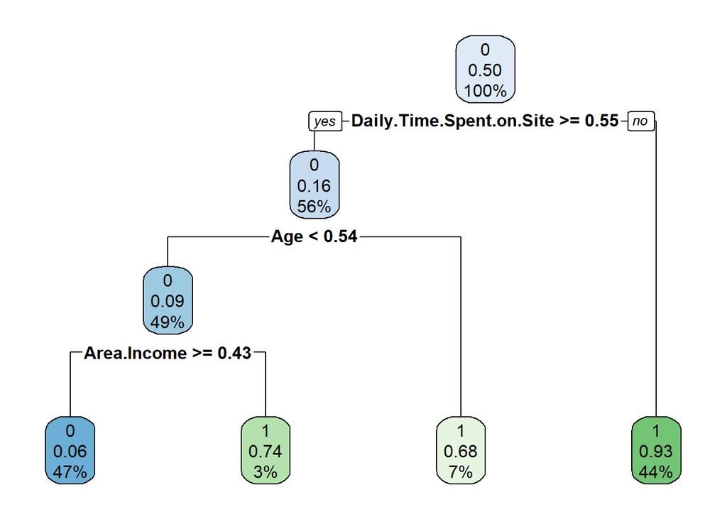

```r
#install.packages("rpart.plot")
library(rpart)
library(rpart.plot)
# fitting and training the model using the decision tree classifier
fit <- rpart(Clicked.on.Ad ~ ., data = training, method = 'class')
rpart.plot(fit, extra = 106)
```

```r
## making predictions
p <- predict(fit, new_dataset, type = "class")
#
# comparing predicted values to actual results
pred <- table(p, new_dataset$Clicked.on.Ad)
pred
```

```
##
## p     0   1
##   0 433  31
##   1  67 469
```

## Getting the model accuracy.

```r
# calculating the accuracy
accuracy_Test <- sum(diag(pred)) / sum(pred)
print(paste('Accuracy:', accuracy_Test))
```

```
## [1] "Accuracy: 0.902"
```

the model gives us the accuracy of 90.2%. the model did a good job.

## Recommendation:

A Decision Tree Model suits best